# Student Wages – Kruskal-Wallis

#### Background

Five different Math 221 courses were given a brief start of semester survey. Two of the variables collected gave information about each student’s class rank and their off-track hourly wage. How much do BYU-Idaho students make hourly during their off-track? Do they earn more as they gain more education?

#### Analysis

Side-by-side boxplots show that in the sample, the Freshman have the highest median wage, while the Sophomores and Seniors have fairly right-skewed distributions with some very high outliers. This suggest that the shape of the distribution of wages is potentially different for the various class ranks. It may be the case that Freshman hourly wages are left skewed, Junior wages are fairly normal, and Sophomore and Senior wages are right-skewed.

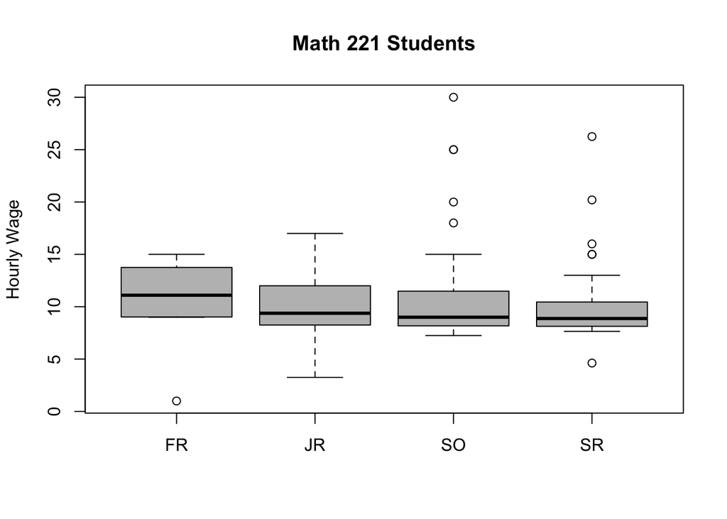

```r
boxplot(Wage ~ as.character(Rank), data=ClassSurvey, type=c("p","a"), col='grey', ylab="Hourly Wage", main="Math 221 Students")
```

The null hypothesis will be that all samples represent a sample of data from the same distribution. The alternative will be that at least one distribution is stochastically dominant over the others. According to the original authors, what the alternative to the Kruskal-Wallis test really is, “is a tendency for observations in at least one of the populations to be larger (or smaller) than all the observations together, when paired randomly. In many cases, this is practically equivalent to the mean of at least one population differing from the others.”

```r
kruskal.test(Wage ~ Rank, data=ClassSurvey)
```

```
    Kruskal-Wallis rank sum test

data:  Wage by Rank
Kruskal-Wallis chi-squared = 2.326, df = 3, p-value = 0.5075
```

There is insufficient evidence to reject the null hypothesis that each of these represents a sample from the same distribution. We will continue to assume that the hourly wage distributions are the same across all class ranks.

#### Interpretation

Since all samples can be assumed to be from the same distribution, Class Rank really has no apparent effect on hourly wages. It sufficies then to simply understand the off-track hourly wage of BYU-Idaho students as a whole. The following histogram summarizes the relevant information. Oddly, some students are reporting earning $5 or less an hour. Most state minimum wages are above $7.25 an hour. So this is surprising. Typically students are earning around $9 (the median) an hour, although some are doing quite well, all the way up to $30 an hour!

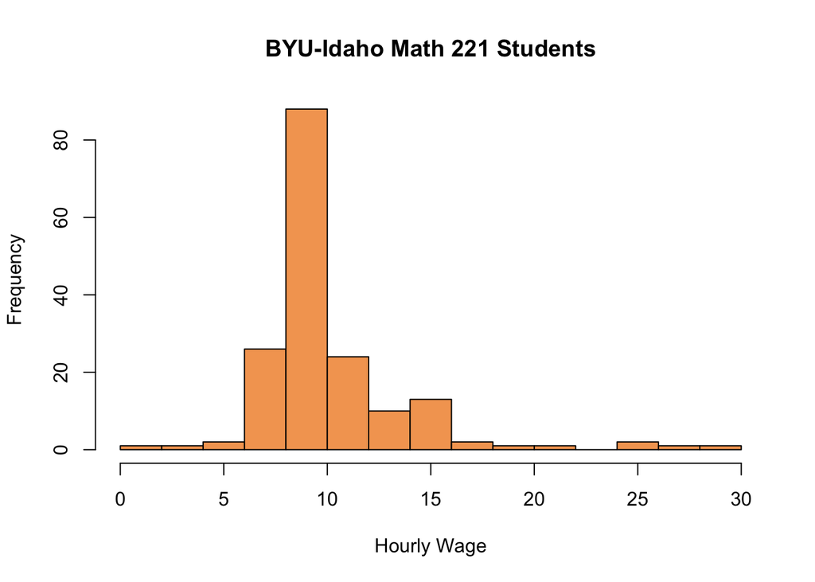

```r
hist(ClassSurvey$Wage, breaks=15, col='sandybrown', xlab="Hourly Wage", main="BYU-Idaho Math 221 Students")
```